# Take-home Exercise 5

This is the 5th take-home exercise in a series of take-home exercises for the Visual Analytics module.In this exercise, we will take the challenge of reveling social areas of the city of Engagement, Ohio USA. Meanwhile visualise and analysi location with traffic bottleneck of the city.

Tianyue Sui (MITB, Singapore Management University)https://scis.smu.edu.sg/  
2022-05-29

# 1. Overview

The take-home exercise provides students the opportunity to revise and practice the R packages and programming skills we learnt in-class at home. This time,the exercise requires students to be innovative and creative by applying appropriate R packages to design enlightening and yet functional data visualization for analytics purposes. Students are encouraged to create multiple data visualization and compare our pros and cons before finalizing the best design.

# 2. Getting Started

Before we get started, it is important for us to ensure that the required R packages have been installed. If yes, we will load the R packages. If they have yet to be installed, we will install the R packages and load them onto R environment.

The chunk code below will do the trick.

```r
packages = c('clock','lubridate', 'ggthemes', 'sftime',
             'tidyverse', 'data.table', 'readr','sf','tmap','rmarkdown')

for (p in packages){
  if(!require(p, character.only = T)){
    install.packages(p)
  }
  library(p,character.only = T)
}
```

# 3. Importing Data

The code chunk below import *TravelJournal.csv* from the data folder into R by using [`read_csv()`](https://readr.tidyverse.org/reference/read_delim.html) of [**readr**](https://readr.tidyverse.org/index.html) and save it as a tibble data frame called *travel*.

And use [`read_sf()`](https://www.rdocumentation.org/packages/sf/versions/0.1-1/topics/read.sf) of [**sf**](https://r-spatial.github.io/sf/), saving it as data frame called *pubs*, *schools*, *apartment*, *buildings*, *employers*, *restaurant*

```r
travel<- read_csv("data/TravelJournal.csv")
travel <- travel %>% mutate(travelEndLocationId = as.character(factor(travelEndLocationId))) %>%
  select(-c(startingBalance,endingBalance,checkInTime,checkOutTime,travelStartLocationId,travelStartTime))

write_rds(travel,"data/travel.rds")
```

```r
pubs <- read_sf("data/Pubs.csv", options = "GEOM_POSSIBLE_NAMES=location")
schools <- read_sf("data/Schools.csv", options = "GEOM_POSSIBLE_NAMES=location")
apartment <- read_sf("data/Apartments.csv", options = "GEOM_POSSIBLE_NAMES=location")
buildings <- read_sf("data/Buildings.csv", options = "GEOM_POSSIBLE_NAMES=location")
employers <- read_sf("data/Employers.csv", options = "GEOM_POSSIBLE_NAMES=location")
restaurant <- read_sf("data/Restaurants.csv", options = "GEOM_POSSIBLE_NAMES=location")
```

# 4.Data Visualizations and Insights

### 4.1 Social Area Detection

Generally the social area is physical or virtual space such as a social center, online social media, or other gathering place where people gather and interact. Thus, to identify physical social area in Ohio, we would get to know participants’ transport purpose. Since the *TravelJournal* already indicated one column with transport purpose, then we can leverage it to extract social purpose data for our specific target according.

To visualize the area, we still need to know polygon information, as *TravelJournal* itself doesn’t contain any polygon data, we need to join this journal with other table.

- tmap_mode() is used to switch the display from static mode
- tm_shape() is used to create a tmap-element that specifies a spatial data object
- tm_polygon() is used to create a tmap-element that draws polygon feature.

```r
travel_social <- left_join(travel, pubs, by = c("travelEndLocationId" = "pubId"))%>%
  filter(purpose == "Recreation (Social Gathering)")
```

```r
write_csv(travel_social,"data/travel_social.csv")
social <- read_sf("data/travel_social.csv",
                options = "GEOM_POSSIBLE_NAMES=location")
```

```r
social <- social %>%
  mutate(travelStartTime = date_time_parse(travelStartTime,zone = "",
                                     format = "%Y-%m-%dT%H:%M:%S"))%>%
  mutate(travelEndTime = date_time_parse(travelEndTime,zone = "",
                                     format = "%Y-%m-%dT%H:%M:%S"))%>%
  mutate(checkInTime = date_time_parse(checkInTime,zone = "",
                                     format = "%Y-%m-%dT%H:%M:%S"))%>%
  mutate(checkOutTime = date_time_parse(checkOutTime,zone = "",
                                     format = "%Y-%m-%dT%H:%M:%S"))%>%
  mutate(startDay = as.numeric(factor(startDay)))%>%
  mutate(endDay = as.numeric(factor(endDay)))
```

```r
social_select <- social %>%
  select(-c(startingBalance,endingBalance,hourlyCost,maxOccupancy))
```

```r
write_rds(social_select,"data/social_select.rds")
```

```r
social_select<- read_rds("data/social_select.rds")
```

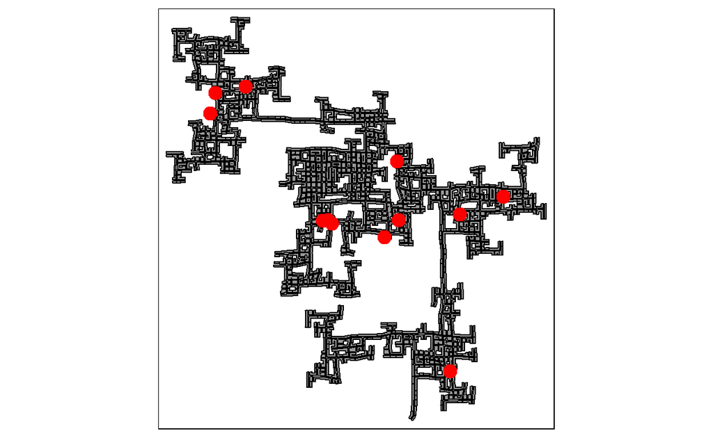

```r
tm_shape(buildings)+
tm_polygons(col = "grey60",
size = 1.2,border.col = "black",border.lwd = 1) +
tm_shape(social_select) +
  tm_dots(col = "red", size = 0.7, alpha = 0.2)
```

### 4.2 Traffic bottleneck

A traffic bottleneck is a localized disruption of vehicular traffic on a street, road, or highway. As opposed to a traffic jam, a bottleneck is a result of a specific physical condition. To define a reasonable metric of traffic bottleneck location, it seems reasonable to monitor number of commuter of a location per 10 minutes instead of total number of a whole day.

As travel data frame doesn’t contain location information detail, we need to leverage and combine location from variable data frames.

```r
apartment_ed <- apartment %>%
  mutate(venueId = apartmentId) %>%
  select(venueId,location)

employer_ed <- employers %>%
  mutate(venueId = employerId) %>%
  select(venueId,location)

pubs_ed<- pubs %>%
  mutate(venueId = pubId) %>%
  select(venueId,location)

school_ed<- schools %>%
  mutate(venueId = schoolId) %>%
  select(venueId,location)

restaurant_ed<- restaurant %>%
  mutate(venueId = restaurantId) %>%
  select(venueId,location)

combine <- rbind(apartment_ed,employer_ed,pubs_ed,school_ed,restaurant_ed)
```

Segregate moring peak and evening peak by time.

```r
morning_peak<- left_join(combine, travel,by = c("venueId" = "travelEndLocationId")) %>%
  mutate(endhour = hour(travelEndTime)) %>%
  filter(endhour %in% c(7,8,9))%>%
  mutate(participantId = as.character(factor(participantId)))
```

```r
morning_peak <- read_rds("data/morning_peak.rds")
```

```r
hex <- st_make_grid(buildings,cellsize=100,square=FALSE) %>%
  st_sf() %>%
  rowid_to_column('hex_id')
```

```r
count_points_in_hex <- st_join(morning_peak,
                        hex,
                        join=st_within) %>%
  st_set_geometry(NULL) %>%
  count(name='pointCount', hex_id) %>%
  mutate(count_per_10min = round(pointCount/(60*2)*10,2))
```

```r
hex_count <- hex %>%
  left_join(count_points_in_hex, by = 'hex_id') %>%
  replace(is.na(.), 0)
```

### Morning peak traffic bottleneck location

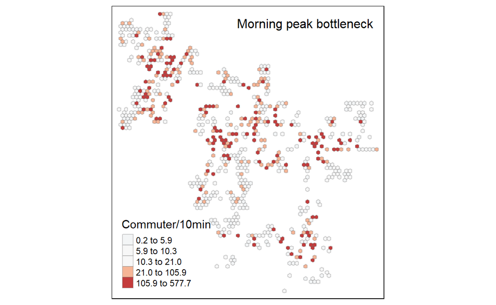

```r
tmap_mode("plot")
tm_shape(hex_count %>%
           filter(count_per_10min > 0))+
  tm_fill("count_per_10min",
          n = 5,
          style = "quantile",
          title = "Commuter/10min",palette="-RdBu") +
  tm_borders(alpha = 0.3)+
  tm_layout(title = "Morning peak bottleneck",title.size = 1, title.position = c("right","top"))
```

```r
tmap_mode("plot")
```

### Evening peak traffic bottleneck location

```r
evening_peak <- read_rds("data/evening_peak.rds")
```

```r
count_evening_in_hex <- st_join(evening_peak,
                        hex,
                        join=st_within) %>%
  st_set_geometry(NULL) %>%
  count(name='pointCount', hex_id) %>%
  mutate(count_per_10min = round(pointCount/(60*2)*10,2))
```

```r
hex_count_evening <- hex %>%
  left_join(count_evening_in_hex, by = 'hex_id') %>%
  replace(is.na(.), 0)
```

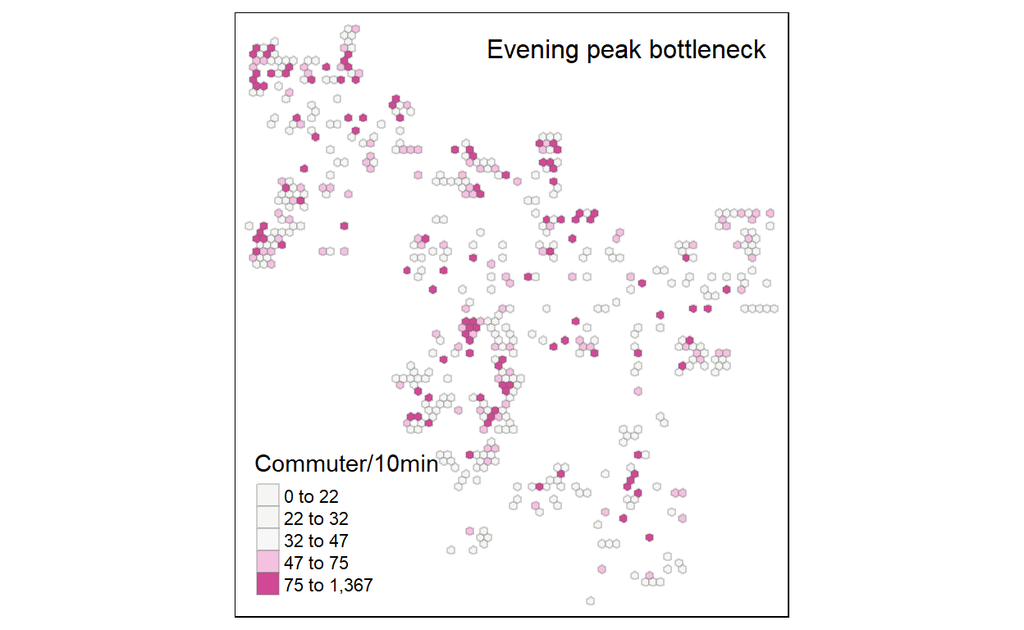

```r
tm_shape(hex_count_evening %>%
           filter(count_per_10min > 0))+
  tm_fill("count_per_10min",
          n = 5,
          style = "quantile",
          title = "Commuter/10min",palette="-PiYG") +
  tm_borders(alpha = 0.3)+
  tm_layout(title = "Evening peak bottleneck",title.size = 1, title.position = c("right","top"))
```